# Analysis of Mario Kart 8 Deluxe's Most Infamous Kart Combination

Kaleb Schmucki

## Introduction

If you have never heard of Mario Kart, essentially, it is a racing game filled with characters and tracks of Nintendo's universe. Mario Kart 8 Deluxe is one of (if not the most) popular and competitive entry in the Mario Kart franchise. Originially, Mario Kart 8 was released for the Wii U in 2014, however, was re-released for the Nintendo Switch in 2017 with the added "Deluxe" to the end of the name. Largely, the mechanics for the games are the same, however, the Deluxe version comes with all the content and some quality-of-life changes from the original one.

Within each Mario Kart game, a player can choose between of a large amount of appearances for their playable character inside the races. In the case of Mario Kart 8 Deluxe (MK8DX), there are 42 characters, 41 vehicle bodies, 22 tires, and 15 gliders. This leads to 568,260 unique combinations (also referred to as "builds") for karts that players can race with. Each of those components have their own set of statistics related to how they perform in-game, which will be discussed more in-depth later.

Now, it is time to introduce the main focus of the document. Mario Kart 8 Deluxe has an online gameplay feature where players can race with other players in real time from all across the world. Each racer has full access to the roster of characters, bodies, tires, and gliders to choose from. Strangely, it is almost guaranteed that each online race will have a majority of players sporting the *exact same kart combination.* This is known to the MK8DX as the infamous Waluigi (character), Wild Wiggler (body), and Rollers (tires) Combination, also referred to as: The Wild Wiggler Combo.

## Enter: The Waluigi-Wild Wiggler-Rollers Combo

As exhibited in the figures section below, the Wild Wiggler Combo is not just a fluke that makes one appearance every couple of races or so. This combination is present in virtually every single online race played.

### Figures

- "[MK8DX] Here's a room with 10 out of 12 Waluigis (and 9 of them are using the same kart combo)" : u/SchnauzerA2B from the MarioKart sub-reddit

[figure not shown]

  link: https://www.reddit.com/r/mariokart/comments/gmnkab/mk8dx_heres_a_room_with_10_out_of_12_waluigis_and/
- "[MK8DX] The absolute state of 20k+ lobbies": u/LanaMK8 from the MarioKart sub-reddit

[figure not shown]

  link: https://www.reddit.com/r/mariokart/comments/ip912m/mk8dx_the_absolute_state_of_20k_lobbies/
- "[MK8DX] This picture basically sums up online": u/Math-Nonsense from the MarioKart sub-reddit

[figure not shown]

  link: https://www.reddit.com/r/mariokart/comments/giu11l/mk8dx_this_picture_basically_sums_up_online/
- "[MK8DX] Character and vehicle diversity": u/newgrrounds from the MarioKart sub-reddit

[figure not shown]

  link: https://www.reddit.com/r/mariokart/comments/i1qr0a/mk8dx_character_and_vehicle_diversity/
- "[MK8DX] went online for the first time in a while. Why does everyone use the same vehicle?" : u/I-Am-The-Yeeter from the MarioKart sub-reddit

[figure not shown]

  link: https://www.reddit.com/r/mariokart/comments/l8tt55/mk8dx_went_online_for_the_first_time_in_a_while/

### Available Data

Why is this the case? As mentioned before, MK8DX is one of the most competitive racing games at this time, and therefore, lots of time and work has been dedicated by the game's community to find the all-time best kart combinations. However, there remains one large problem when working data analysis on Mario Kart, or for any Nintendo games for that matter. Unfortunately, Nintendo does not have a public database or API for any of their games. All data analysis done by the Nintendo community work on datasets collected by the community. What that means for MK8DX is that it is difficult to measure the affect that any kart combination has on the outcome of races, since the outcomes of races is not an already existing dataset. Because of this reason, the data analysis that I conduct will be purely on the statistics of the karts themselves, which affect how they perform in races.

## Hypothesis

I state the hypothesis here before beginning the data analysis part of the pipeline to ensure I keep to my word. Once we reach that part, I will more specifically state how the hypotheses will be accepted or rejected in terms of the data visualized.The hypothesis that will be tested is if the Waluigi-Wild Wiggler-Rollers combination holds the top place in any of the statistics available to these karts, or whether this popular combination is simply overhyped by the MK8DX community. We will accept or reject the null hypothesis

- Null Hypothesis: The Waluigi-Wild Wiggler-Rollers combination holds no top place in any of the statistics categories
- Alternative Hypothesis: The Waluigi-Wild Wiggler-Rollers combination holds at least one top place in any of the statistics categories

## Data Collection

The data is gathered from the Mario Kart 8 Deluxe wiki page, where they have charts for all statistics for the build components.

- Mario Kart 8 Deluxe Wiki Link: https://www.mariowiki.com/Mario_Kart_8_Deluxe_in-game_statistics

```python
#this code block requests the mario kart wiki page and retrieves the tables shown on that page.
#then I put the relevant tables (for driver, kart body, kart tires, and kart gliders) into data frames
import requests
import pandas as pd

mk8wiki = "https://www.mariowiki.com/Mario_Kart_8_Deluxe_in-game_statistics"
request = requests.get(mk8wiki).content

#create the data frames
table_list = pd.read_html(request)
body_df = table_list[1]
driver_df = table_list[2].loc[0:43]
tire_df = table_list[3]
glider_df = table_list[4]
```

## Data Processing

### Comprehending the Data

Before we begin data analysis and visualization, it is important to comprehend the data we have collected, and ensure we are only working with the data needed. I look to the Mario Kart 8 Deluxe wikipedia page to gather the character and kart data needed, as well as a comprehensive guide on how each stat affects the in-game races.

The acronyms for Gound, Water, Anti-Gravity, and Air can be confusing. For example, why is ground "L" while air is "G" and anti-gravity "A"? It is easiest to remember it this way. The "Speeds" are marked with an "S" for speed, the "Handlings" are marked with "T" for turning, then:

- Ground = L for Land
- Water = W for Water
- Anti-Gravity = A for Anti
- Air = G for Gliding

Remember, a build consists 1 character, 1 body, 1 tire set, and 1 glider, and each of those have a set of stats listed above. The full combination's (or "build's") stats are calculated by adding each of the individual componenet's stats for their respective categories. For instance, if we were to use the Standart Kart (body, weight 2), Mario (character, weight 6), Standard Tires (tires, weight 2), and the Super Glider (glider, weight 1), the weight for the entire build would be 11.

### Notes on Playable Characters

The final count of playable drivers according to the Mario Kart Wiki is 42, however, there are some footnotes that need to be discussed regarding that final count.

#### Alternate Costumes

Although the character select screen only has 42 choices, certain characters allow you to choose alternate costumes for them. This changes the appearance of the driver through the race, and does not change their statistics. However, there are two alternate costumes that have their own set of statistics in the game's files, but they are exact copies of their normal driver's statistics. These driver/alternate relationships that have separate stats files (even though they are identical) are listed below.

- Metal Mario/Gold Mario
- Link/Breath of the Wild Link

These are the only 2 costumes out of the total 22 alternate costumes that have their own data. Since they are copies, I will remove their entries from the driver's dataframe, and deal with them as if they were their original driver.

#### Miis

This note is for those who are familiar with Mario Kart 8 Deluxe and notice that the driver chart is missing something. There are 2 more playable characters that are unnacounted for, but explained here as to why. In most all Nintendo gaming products, users can create a "Mii," a personal, customizable avatar that Nintendo often incorporates as playable characters in their games. They follow this trend with Mario Kart 8 Deluxe, where players are able to drive as their custom Mii characters. There are also 3 pre-determined size categories for drivers in MK8DX: small, medium, and large. Since Mii's can be used as drivers, and Mii's are fully customizable (including their height and weight), the MK8DX developers needed to add stats for the Mii drivers as well.

The way they implemented this was to have a threshold for Miis that separated them into the 3 MK8DX size categories. Medium-sized Miis have their own custom set of stats, seen in the dataframe below. However, large-sized Miis are programmed to have the same statistics as Bowser, and small-sized Miis are programmed to have the same statistics as Baby Mario. Therefore, they are excluded from entries in the data, and don't count towards the full 42 total unique playable characters.

### Data Wrangling

The original dataframes are formatted in a way that makes exploratory analysis difficult. Instead of having a column for each attribute, they have a multi-indexed column, where the outer index is essentially just the name of the table, and the inner index is the actual statistical attribute. To reset each table from multi-indexed columns to single indexed dataframe I do the following: iterate through the column headers, which is represented as a tuple where the desired value is in index 1, then set that deisred value to the column name.

Additionally, all the values in the 4 dataframes that are supposed to be integers are strings, so I need to cast these over.

Lastly, I don't need to perform any missing-data processes since all the data is accounted for in the tables

```python
#The following code blocks process the data as discussed aboves
driver_df = driver_df.drop([37,43]) #Drop Link BOTW Costume and Drop Golden Mario Costume
driver_df = driver_df.reset_index(drop=True)
```

```python
#iterate through the multi-index column names (represented as tuples) and reset the frame columns to single-index with the name we desire
driver_df.columns = [col[1] for col in driver_df.columns]
body_df.columns = [col[1] for col in body_df.columns]
tire_df.columns = [col[1] for col in tire_df.columns]
glider_df.columns = [col[1] for col in glider_df.columns]
```

```python
#cast each numerical data item from string to int
for i in range(1,14):
    driver_df.iloc[:,i] = driver_df.iloc[:,i].astype(int)
    body_df.iloc[:,i] = body_df.iloc[:,i].astype(int)
    tire_df.iloc[:,i] = tire_df.iloc[:,i].astype(int)
    glider_df.iloc[:,i] = glider_df.iloc[:,i].astype(int)
```

### All Unique Builds/Combinations

As explained before, each build contains 1 item from each category, and the build's stats are set to the sum of all the component's stats. Although there are 568,260 combinations of karts and drivers to choose from, there are less statistically unique combinations. Meaning, multiple builds may be made up of unique components, but their full build statistics could still be the same.

In this section I create a new dataframe of all the *statistically unique* builds. The name column will be the names of all builds that have the associated build stats.

```python
#this code block creates a dataframe holding every statistically UNIQUE kart combination
#this import is used as a loading bar, so I can see how long until the dataframe is complete

from tqdm.notebook import tqdm as tqdm

all_builds = pd.DataFrame(columns=["WG", "AC", "ON", "OF", "MT", "SL", "SW", "SA", "SG", "TL", "TW", "TA", "TG"])
total_builds = 0

for i, j in tqdm(driver_df.iterrows()):
    for k, l in body_df.iterrows():
        for m, n in tire_df.iterrows():
            for o, p in glider_df.iterrows():
                wgs = j.WG + l.WG + n.WG + p.WG
                acs = j.AC + l.AC + n.AC + p.AC
                ons = j.ON + l.ON + n.ON + p.ON
                ofs = j.OF + l.OF + n.OF + p.OF
                mts = j.MT + l.MT + n.MT + p.MT
                sls = j.SL + l.SL + n.SL + p.SL
                sws = j.SW + l.SW + n.SW + p.SW
                sas = j.SA + l.SA + n.SA + p.SA
                sgs = j.SG + l.SG + n.SG + p.SG
                tls = j.TL + l.TL + n.TL + p.TL
                tws = j.TW + l.TW + n.TW + p.TW
                tas = j.TA + l.TA + n.TA + p.TA
                tgs = j.TG + l.TG + n.TG + p.TG

                if(not (((all_builds["WG"] == wgs) & (all_builds["AC"] == acs) & (all_builds["ON"] == ons) & (all_builds["OF"] == ofs) & (all_builds["MT"] == mts) & (all_builds["SL"] == sls) & (all_builds["SW"] == sws) & (all_builds["SA"] == sas) & (all_builds["SG"] == sgs) & (all_builds["TL"] == tls) & (all_builds["TW"] == tws) & (all_builds["TA"] == tas) & (all_builds["TG"] == tgs)).any())):
                    all_builds.at[total_builds] = [wgs, acs, ons, ofs, mts, sls, sws, sas, sgs, tls, tws, tas, tgs]
                    total_builds = total_builds + 1

print("Total Unique Builds:", total_builds)
```

```
0it [00:00, ?it/s]
```

```
Total Unique Builds: 8064
```

## Exploratory Analysis and Data Visualization

Now, with all the Mario Kart 8 Deluxe data wrangled, I can start the exploratory analysis and visualization phase. Firstly, for future reference, here are the dataframes visualized.

### DataFrames

```python
#this code block shows all the data frames I've created for exploratory analysis and visualization
print("Driver Dataframe:")
display(driver_df)
print("Body Dataframe:")
display(body_df)
print("Tire Dataframe:")
display(tire_df)
print("Glider Dataframe:")
display(glider_df)
print("All Unique Statistical Combinations:")
display(all_builds)
```

```
Driver Dataframe:
```

|  | Driver | WG | AC | ON | OF | MT | SL | SW | SA | SG | TL | TW | TA | TG |
| --- | --- | --- | --- | --- | --- | --- | --- | --- | --- | --- | --- | --- | --- | --- |
| 0 | MarioMro | 6 | 2 | 4 | 2 | 2 | 6 | 6 | 6 | 6 | 4 | 4 | 4 | 4 |
| 1 | LuigiLig | 6 | 2 | 5 | 1 | 2 | 6 | 6 | 6 | 6 | 5 | 5 | 5 | 5 |
| 2 | PeachPch | 4 | 3 | 3 | 3 | 3 | 5 | 5 | 5 | 5 | 5 | 5 | 5 | 5 |
| 3 | DaisyDsy | 4 | 3 | 3 | 3 | 3 | 5 | 5 | 5 | 5 | 5 | 5 | 5 | 5 |
| 4 | YoshiYsi1 | 4 | 3 | 3 | 3 | 3 | 5 | 5 | 5 | 5 | 5 | 5 | 5 | 5 |
| 5 | ToadKno | 3 | 4 | 3 | 4 | 3 | 3 | 3 | 3 | 3 | 7 | 7 | 7 | 7 |
| 6 | ToadetteKnc | 2 | 5 | 4 | 2 | 4 | 2 | 2 | 2 | 2 | 7 | 7 | 7 | 7 |
| 7 | Koopa TroopaNok | 2 | 4 | 1 | 5 | 4 | 2 | 2 | 2 | 2 | 8 | 8 | 8 | 8 |
| 8 | BowserKop2 | 10 | 0 | 6 | 0 | 0 | 10 | 10 | 10 | 10 | 0 | 0 | 0 | 0 |
| 9 | Donkey KongDkg | 8 | 1 | 10 | 0 | 1 | 9 | 9 | 9 | 9 | 2 | 2 | 2 | 2 |
| 10 | WarioWro | 9 | 0 | 5 | 1 | 0 | 10 | 10 | 10 | 10 | 1 | 1 | 1 | 1 |
| 11 | WaluigiWlg | 8 | 1 | 10 | 0 | 1 | 9 | 9 | 9 | 9 | 2 | 2 | 2 | 2 |
| 12 | RosalinaRst | 7 | 1 | 9 | 3 | 2 | 7 | 7 | 7 | 7 | 3 | 3 | 3 | 3 |
| 13 | Metal MarioMroM | 10 | 1 | 8 | 1 | 1 | 8 | 8 | 8 | 8 | 3 | 3 | 3 | 3 |
| 14 | Pink Gold PeachPchG | 10 | 1 | 8 | 1 | 1 | 8 | 8 | 8 | 8 | 3 | 3 | 3 | 3 |
| 15 | LakituJgm | 2 | 4 | 1 | 5 | 4 | 2 | 2 | 2 | 2 | 8 | 8 | 8 | 8 |
| 16 | Shy GuyHyh1 | 3 | 4 | 3 | 4 | 3 | 3 | 3 | 3 | 3 | 7 | 7 | 7 | 7 |
| 17 | Baby MarioMroB3 | 1 | 5 | 2 | 4 | 4 | 1 | 1 | 1 | 1 | 8 | 8 | 8 | 8 |
| 18 | Baby LuigiLigB | 1 | 5 | 2 | 4 | 4 | 1 | 1 | 1 | 1 | 8 | 8 | 8 | 8 |
| 19 | Baby PeachPchB | 0 | 4 | 3 | 5 | 5 | 0 | 0 | 0 | 0 | 10 | 10 | 10 | 10 |
| 20 | Baby DaisyDsyB | 0 | 4 | 3 | 5 | 5 | 0 | 0 | 0 | 0 | 10 | 10 | 10 | 10 |
| 21 | Baby RosalinaRstB | 0 | 5 | 4 | 3 | 5 | 0 | 0 | 0 | 0 | 9 | 9 | 9 | 9 |
| 22 | LarryLry | 3 | 4 | 3 | 4 | 3 | 3 | 3 | 3 | 3 | 7 | 7 | 7 | 7 |
| 23 | LemmyLmy | 0 | 5 | 4 | 3 | 5 | 0 | 0 | 0 | 0 | 9 | 9 | 9 | 9 |
| 24 | WendyWdy | 2 | 5 | 4 | 2 | 4 | 2 | 2 | 2 | 2 | 7 | 7 | 7 | 7 |
| 25 | LudwigLdw | 6 | 2 | 4 | 2 | 2 | 6 | 6 | 6 | 6 | 4 | 4 | 4 | 4 |
| 26 | IggyIgy | 6 | 2 | 5 | 1 | 2 | 6 | 6 | 6 | 6 | 5 | 5 | 5 | 5 |
| 27 | RoyRoy | 8 | 1 | 10 | 0 | 1 | 9 | 9 | 9 | 9 | 2 | 2 | 2 | 2 |
| 28 | MortonMtn | 10 | 0 | 6 | 0 | 0 | 10 | 10 | 10 | 10 | 0 | 0 | 0 | 0 |
| 29 | Mii (medium)MiiM | 6 | 2 | 4 | 2 | 2 | 6 | 6 | 6 | 6 | 4 | 4 | 4 | 4 |
| 30 | Tanooki MarioMroT | 5 | 3 | 7 | 1 | 3 | 5 | 5 | 5 | 5 | 5 | 5 | 5 | 5 |
| 31 | LinkLnk | 7 | 1 | 9 | 3 | 2 | 7 | 7 | 7 | 7 | 3 | 3 | 3 | 3 |
| 32 | Villager (male)Mrb | 5 | 3 | 7 | 1 | 3 | 5 | 5 | 5 | 5 | 5 | 5 | 5 | 5 |
| 33 | IsabelleShz | 2 | 5 | 4 | 2 | 4 | 2 | 2 | 2 | 2 | 7 | 7 | 7 | 7 |
| 34 | Cat PeachPchC | 3 | 4 | 2 | 3 | 3 | 4 | 4 | 4 | 4 | 6 | 6 | 6 | 6 |
| 35 | Dry BowserKopB | 9 | 0 | 5 | 1 | 0 | 10 | 10 | 10 | 10 | 1 | 1 | 1 | 1 |
| 36 | Villager (female)Mrg | 3 | 4 | 2 | 3 | 3 | 4 | 4 | 4 | 4 | 6 | 6 | 6 | 6 |
| 37 | Dry BonesKrn | 1 | 5 | 2 | 4 | 4 | 1 | 1 | 1 | 1 | 8 | 8 | 8 | 8 |
| 38 | Bowser Jr.KopJ | 2 | 4 | 1 | 5 | 4 | 2 | 2 | 2 | 2 | 8 | 8 | 8 | 8 |
| 39 | King BooKtr | 7 | 1 | 9 | 3 | 2 | 7 | 7 | 7 | 7 | 3 | 3 | 3 | 3 |
| 40 | Inkling GirlSpg1 | 3 | 4 | 2 | 3 | 3 | 4 | 4 | 4 | 4 | 6 | 6 | 6 | 6 |
| 41 | Inkling BoySpb1 | 5 | 3 | 7 | 1 | 3 | 5 | 5 | 5 | 5 | 5 | 5 | 5 | 5 |

```
Body Dataframe:
```

|  | Body | WG | AC | ON | OF | MT | SL | SW | SA | SG | TL | TW | TA | TG |
| --- | --- | --- | --- | --- | --- | --- | --- | --- | --- | --- | --- | --- | --- | --- |
| 0 | Standard Kart | 2 | 4 | 3 | 3 | 4 | 3 | 3 | 3 | 3 | 3 | 2 | 3 | 3 |
| 1 | Pipe Frame | 1 | 6 | 3 | 4 | 6 | 1 | 3 | 1 | 1 | 5 | 4 | 4 | 2 |
| 2 | Mach 8 | 3 | 3 | 2 | 4 | 4 | 3 | 3 | 5 | 4 | 2 | 2 | 4 | 2 |
| 3 | Steel Driver | 4 | 1 | 1 | 3 | 2 | 4 | 5 | 2 | 0 | 1 | 5 | 1 | 1 |
| 4 | Cat Cruiser | 2 | 5 | 4 | 3 | 5 | 2 | 2 | 3 | 4 | 4 | 2 | 3 | 4 |
| 5 | Circuit Special | 3 | 1 | 3 | 1 | 1 | 5 | 1 | 4 | 2 | 1 | 1 | 2 | 0 |
| 6 | Tri-Speeder | 4 | 1 | 1 | 3 | 2 | 4 | 5 | 2 | 0 | 1 | 5 | 1 | 1 |
| 7 | Badwagon | 4 | 0 | 2 | 5 | 0 | 5 | 2 | 3 | 1 | 0 | 1 | 1 | 0 |
| 8 | Prancer | 1 | 2 | 1 | 2 | 3 | 4 | 3 | 3 | 3 | 3 | 3 | 2 | 3 |
| 9 | BiddybuggyBuggybud | 0 | 7 | 1 | 4 | 7 | 0 | 1 | 2 | 1 | 5 | 4 | 5 | 4 |
| 10 | Landship | 0 | 6 | 0 | 6 | 6 | 1 | 5 | 0 | 2 | 4 | 5 | 2 | 3 |
| 11 | SneekerBounder | 2 | 2 | 1 | 0 | 3 | 4 | 2 | 3 | 3 | 3 | 2 | 3 | 2 |
| 12 | Sports CoupeSports Coupé | 3 | 3 | 2 | 4 | 4 | 3 | 3 | 5 | 4 | 2 | 2 | 4 | 2 |
| 13 | Gold StandardGold Kart | 2 | 2 | 1 | 0 | 3 | 4 | 2 | 3 | 3 | 3 | 2 | 3 | 2 |
| 14 | Standard Bike | 1 | 5 | 3 | 5 | 5 | 2 | 2 | 4 | 3 | 4 | 3 | 4 | 3 |
| 15 | Comet | 2 | 5 | 4 | 3 | 5 | 2 | 2 | 3 | 4 | 4 | 2 | 3 | 4 |
| 16 | Sport Bike | 1 | 2 | 1 | 2 | 3 | 4 | 3 | 3 | 3 | 3 | 3 | 2 | 3 |
| 17 | The Duke | 2 | 4 | 3 | 3 | 4 | 3 | 3 | 3 | 3 | 3 | 2 | 3 | 3 |
| 18 | Flame Rider | 1 | 5 | 3 | 5 | 5 | 2 | 2 | 4 | 3 | 4 | 3 | 4 | 3 |
| 19 | Varmint | 1 | 6 | 3 | 4 | 6 | 1 | 3 | 1 | 1 | 5 | 4 | 4 | 2 |
| 20 | Mr. ScootyMr Scooty | 0 | 7 | 1 | 4 | 7 | 0 | 1 | 2 | 1 | 5 | 4 | 5 | 4 |
| 21 | Jet Bike | 1 | 2 | 1 | 2 | 3 | 4 | 3 | 3 | 3 | 3 | 3 | 2 | 3 |
| 22 | Yoshi Bike | 2 | 5 | 4 | 3 | 5 | 2 | 2 | 3 | 4 | 4 | 2 | 3 | 4 |
| 23 | Standard ATVStandard Quad | 4 | 0 | 2 | 5 | 0 | 5 | 2 | 3 | 1 | 0 | 1 | 1 | 0 |
| 24 | Wild Wiggler | 1 | 5 | 3 | 5 | 5 | 2 | 2 | 4 | 3 | 4 | 3 | 4 | 3 |
| 25 | Teddy Buggy | 2 | 5 | 4 | 3 | 5 | 2 | 2 | 3 | 4 | 4 | 2 | 3 | 4 |
| 26 | GLA | 4 | 0 | 2 | 5 | 0 | 5 | 2 | 3 | 1 | 0 | 1 | 1 | 0 |
| 27 | W 25 Silver Arrow | 1 | 5 | 3 | 5 | 5 | 2 | 2 | 4 | 3 | 4 | 3 | 4 | 3 |
| 28 | 300 SL Roadster | 2 | 4 | 3 | 3 | 4 | 3 | 3 | 3 | 3 | 3 | 2 | 3 | 3 |
| 29 | Blue Falcon | 0 | 3 | 1 | 3 | 3 | 4 | 2 | 4 | 3 | 2 | 3 | 5 | 1 |
| 30 | Tanooki Kart | 3 | 2 | 4 | 7 | 3 | 2 | 4 | 3 | 3 | 4 | 4 | 3 | 3 |
| 31 | B Dasher | 3 | 1 | 3 | 1 | 1 | 5 | 1 | 4 | 2 | 1 | 1 | 2 | 0 |
| 32 | Master Cycle | 2 | 2 | 1 | 0 | 3 | 4 | 2 | 3 | 3 | 3 | 2 | 3 | 2 |
| 33 | Streetle | 0 | 6 | 0 | 6 | 6 | 1 | 5 | 0 | 2 | 4 | 5 | 2 | 3 |
| 34 | P-Wing | 3 | 1 | 3 | 1 | 1 | 5 | 1 | 4 | 2 | 1 | 1 | 2 | 0 |
| 35 | City Tripper | 1 | 6 | 3 | 4 | 6 | 1 | 3 | 1 | 1 | 5 | 4 | 4 | 2 |
| 36 | Bone Rattler | 4 | 1 | 1 | 3 | 2 | 4 | 5 | 2 | 0 | 1 | 5 | 1 | 1 |
| 37 | Koopa Clown | 3 | 2 | 4 | 7 | 3 | 2 | 4 | 3 | 3 | 4 | 4 | 3 | 3 |
| 38 | Splat Buggy | 0 | 3 | 1 | 3 | 3 | 4 | 2 | 4 | 3 | 2 | 3 | 5 | 1 |
| 39 | Inkstriker | 3 | 3 | 2 | 4 | 4 | 3 | 3 | 5 | 4 | 2 | 2 | 4 | 2 |
| 40 | Master Cycle Zero | 3 | 2 | 4 | 7 | 3 | 2 | 4 | 3 | 3 | 4 | 4 | 3 | 3 |

```
Tire Dataframe:
```

|  | Tire | WG | AC | ON | OF | MT | SL | SW | SA | SG | TL | TW | TA | TG |
| --- | --- | --- | --- | --- | --- | --- | --- | --- | --- | --- | --- | --- | --- | --- |
| 0 | StandardNormal | 2 | 4 | 2 | 5 | 3 | 2 | 3 | 2 | 3 | 3 | 3 | 3 | 3 |
| 1 | Monster | 4 | 2 | 3 | 7 | 2 | 2 | 2 | 2 | 1 | 0 | 1 | 0 | 1 |
| 2 | Roller | 0 | 6 | 0 | 4 | 6 | 0 | 3 | 0 | 3 | 4 | 4 | 4 | 4 |
| 3 | Slim | 2 | 2 | 4 | 1 | 2 | 3 | 2 | 4 | 2 | 4 | 4 | 3 | 4 |
| 4 | Slick | 3 | 1 | 4 | 0 | 0 | 4 | 0 | 4 | 0 | 2 | 0 | 2 | 1 |
| 5 | Metal | 4 | 0 | 1 | 2 | 0 | 4 | 3 | 1 | 2 | 2 | 2 | 1 | 0 |
| 6 | Button | 0 | 5 | 1 | 3 | 5 | 1 | 2 | 2 | 2 | 3 | 3 | 4 | 2 |
| 7 | Off-Road | 3 | 3 | 3 | 6 | 1 | 3 | 4 | 2 | 1 | 1 | 1 | 2 | 2 |
| 8 | Sponge | 1 | 4 | 2 | 6 | 4 | 1 | 1 | 1 | 4 | 2 | 1 | 2 | 3 |
| 9 | WoodWooden | 2 | 2 | 4 | 1 | 2 | 3 | 2 | 4 | 2 | 4 | 4 | 3 | 4 |
| 10 | Cushion | 1 | 4 | 2 | 6 | 4 | 1 | 1 | 1 | 4 | 2 | 1 | 2 | 3 |
| 11 | Blue StandardNormal Blue | 2 | 4 | 2 | 5 | 3 | 2 | 3 | 2 | 3 | 3 | 3 | 3 | 3 |
| 12 | Hot MonsterFunky Monster | 4 | 2 | 3 | 7 | 2 | 2 | 2 | 2 | 1 | 0 | 1 | 0 | 1 |
| 13 | Azure Roller | 0 | 6 | 0 | 4 | 6 | 0 | 3 | 0 | 3 | 4 | 4 | 4 | 4 |
| 14 | Crimson Slim | 2 | 2 | 4 | 1 | 2 | 3 | 2 | 4 | 2 | 4 | 4 | 3 | 4 |
| 15 | Cyber Slick | 3 | 1 | 4 | 0 | 0 | 4 | 0 | 4 | 0 | 2 | 0 | 2 | 1 |
| 16 | Retro Off-Road | 3 | 3 | 3 | 6 | 1 | 3 | 4 | 2 | 1 | 1 | 1 | 2 | 2 |
| 17 | Gold TiresGold Wheels | 4 | 0 | 1 | 2 | 0 | 4 | 3 | 1 | 2 | 2 | 2 | 1 | 0 |
| 18 | GLA TiresGLA Wheels | 2 | 4 | 2 | 5 | 3 | 2 | 3 | 2 | 3 | 3 | 3 | 3 | 3 |
| 19 | Triforce TiresTriforce Tyres | 3 | 3 | 3 | 6 | 1 | 3 | 4 | 2 | 1 | 1 | 1 | 2 | 2 |
| 20 | Leaf TiresLeaf Tyres | 0 | 5 | 1 | 3 | 5 | 1 | 2 | 2 | 2 | 3 | 3 | 4 | 2 |
| 21 | Ancient TiresAncient Tyres | 4 | 2 | 3 | 7 | 2 | 2 | 2 | 2 | 1 | 0 | 1 | 0 | 1 |

```
Glider Dataframe:
```

|  | Glider | WG | AC | ON | OF | MT | SL | SW | SA | SG | TL | TW | TA | TG |
| --- | --- | --- | --- | --- | --- | --- | --- | --- | --- | --- | --- | --- | --- | --- |
| 0 | Super Glider | 1 | 1 | 1 | 1 | 1 | 1 | 1 | 0 | 2 | 1 | 0 | 1 | 1 |
| 1 | Cloud Glider | 0 | 2 | 1 | 1 | 2 | 0 | 1 | 1 | 1 | 1 | 0 | 1 | 2 |
| 2 | Wario Wing | 2 | 1 | 2 | 0 | 1 | 1 | 0 | 1 | 2 | 1 | 1 | 0 | 1 |
| 3 | Waddle Wing | 1 | 1 | 1 | 1 | 1 | 1 | 1 | 0 | 2 | 1 | 0 | 1 | 1 |
| 4 | Peach Parasol | 1 | 2 | 2 | 0 | 2 | 0 | 0 | 1 | 1 | 1 | 1 | 0 | 2 |
| 5 | Parachute | 0 | 2 | 1 | 1 | 2 | 0 | 1 | 1 | 1 | 1 | 0 | 1 | 2 |
| 6 | Parafoil | 1 | 2 | 2 | 0 | 2 | 0 | 0 | 1 | 1 | 1 | 1 | 0 | 2 |
| 7 | Flower Glider | 0 | 2 | 1 | 1 | 2 | 0 | 1 | 1 | 1 | 1 | 0 | 1 | 2 |
| 8 | Bowser Kite | 1 | 2 | 2 | 0 | 2 | 0 | 0 | 1 | 1 | 1 | 1 | 0 | 2 |
| 9 | Plane Glider | 2 | 1 | 2 | 0 | 1 | 1 | 0 | 1 | 2 | 1 | 1 | 0 | 1 |
| 10 | MKTV Parafoil | 1 | 2 | 2 | 0 | 2 | 0 | 0 | 1 | 1 | 1 | 1 | 0 | 2 |
| 11 | Gold Glider | 2 | 1 | 2 | 0 | 1 | 1 | 0 | 1 | 2 | 1 | 1 | 0 | 1 |
| 12 | Hylian Kite | 1 | 1 | 1 | 1 | 1 | 1 | 1 | 0 | 2 | 1 | 0 | 1 | 1 |
| 13 | Paper Glider | 0 | 2 | 1 | 1 | 2 | 0 | 1 | 1 | 1 | 1 | 0 | 1 | 2 |
| 14 | Paraglider | 2 | 1 | 2 | 0 | 1 | 1 | 0 | 1 | 2 | 1 | 1 | 0 | 1 |

```
All Unique Statistical Combinations:
```

|  | WG | AC | ON | OF | MT | SL | SW | SA | SG | TL | TW | TA | TG |
| --- | --- | --- | --- | --- | --- | --- | --- | --- | --- | --- | --- | --- | --- |
| 0 | 11 | 11 | 10 | 11 | 10 | 12 | 13 | 11 | 14 | 11 | 9 | 11 | 11 |
| 1 | 10 | 12 | 10 | 11 | 11 | 11 | 13 | 12 | 13 | 11 | 9 | 11 | 12 |
| 2 | 12 | 11 | 11 | 10 | 10 | 12 | 12 | 12 | 14 | 11 | 10 | 10 | 11 |
| 3 | 11 | 12 | 11 | 10 | 11 | 11 | 12 | 12 | 13 | 11 | 10 | 10 | 12 |
| 4 | 13 | 9 | 11 | 13 | 9 | 12 | 12 | 11 | 12 | 8 | 7 | 8 | 9 |
| ... | ... | ... | ... | ... | ... | ... | ... | ... | ... | ... | ... | ... | ... |
| 8059 | 10 | 11 | 11 | 16 | 9 | 9 | 12 | 10 | 9 | 12 | 12 | 11 | 13 |
| 8060 | 8 | 11 | 9 | 17 | 11 | 8 | 10 | 8 | 13 | 13 | 11 | 12 | 13 |
| 8061 | 7 | 12 | 9 | 17 | 12 | 7 | 10 | 9 | 12 | 13 | 11 | 12 | 14 |
| 8062 | 9 | 11 | 10 | 16 | 11 | 8 | 9 | 9 | 13 | 13 | 12 | 11 | 13 |
| 8063 | 8 | 12 | 10 | 16 | 12 | 7 | 9 | 9 | 12 | 13 | 12 | 11 | 14 |

8064 rows × 13 columns

### What to Plot?

Before plotting, it is import to understand what to plot and why it needs to be plotted. Because our hypothesis is centered around the Waluigi, Wild-Wiggler, Rollers combo holding any top places within the statistics, it goes to say that I should plot the stats for each of the unique combinations. I will do this, but firstly, I want to go in-depth on the most import stats from the set.

The most important issue in the Speed vs Acceleration debate is that the statistics are designed such that no build can a high speed stat *and* a high acceleration stat. This is actually the case for multiple pairs of statistics, however, they are not as important as these.

Links to community conversations and debates on the matter:

- Speed vs Accl MK8DX: https://www.reddit.com/r/mariokart/comments/6agkrg/is_speed_or_acceleration_more_valuable_in_mk8/
- Speed vs Accl MK8DX: https://gamefaqs.gamespot.com/boards/200276-mario-kart-8-deluxe/75465010
- An argument for both MK8DX: https://www.reddit.com/r/MarioKart8Deluxe/comments/pmytr7/whats_the_best_kart_combination/

This issue is not unique to Mario Kart 8 Deluxe either, rather an ongoing debate for each entry in the series:

- Speed vs Accl, Mario Kart Wii: https://www.neoseeker.com/forums/36648/t1163731-speed-acceleration/

### Plotting

With the above arguments stated, I will first focus on these 3 stats, since they are largely agreed to be the most influential, before moving on to plot the remainder of the stats.

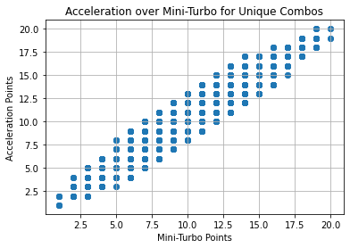

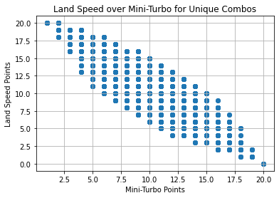

[figure not shown]

```python
import matplotlib as mpl
import matplotlib.pyplot as plt
import numpy as np

plt.scatter(all_builds['MT'], all_builds['AC'])
plt.xlabel("Mini-Turbo Points")
plt.ylabel("Acceleration Points")
plt.title("Acceleration over Mini-Turbo for Unique Combos")
plt.grid()
plt.show()

plt.scatter(all_builds['MT'], all_builds['SL'])
plt.xlabel("Mini-Turbo Points")
plt.ylabel("Land Speed Points")
plt.title("Land Speed over Mini-Turbo for Unique Combos")
plt.grid()
plt.show()

plt.scatter(all_builds['SL'], all_builds['AC'])
plt.xlabel("Acceleration Points")
plt.ylabel("Land Speed Points")
plt.title("Land Speed over Acceleration for Unique Combos")
plt.grid()
plt.show()
```

### Summary of Visuals

In the above scatterplots, it is plain to see the positive correlation between Acceleration and Mini-Turbo, as well as the negative correlation between Speed and Mini-Turbo/Acceleration. The second one is easily explainable: Mini-Turbo is a stat that rewards players for taking turns well by re-accelerating them (with a boost) back into the game. Another fact is that turning slows you down. If there existed cars that had a high Mini-Turbo stat, and a high Top-Speed stat, that build would not suffer from taking turns *at all,* which would make that build extraordinarily effective.

The same reasoning stands for the Top-Speed vs Acceleration relationship, if a build had good of both, their would be no reason not to use that build. In a way, Mini-Turbo is related to both Acceleration and Top-Speed:

- Mini-Turbo and Accl: Where Accleration is the stat that determines how fast a player speeds up to their top speed, Mini-Turbo is the stat that says how fast players speed up after a turn (through a rewarded boost). So essentially, Mini-Turbo is the Acceleration of turns.
- Mini-Turbo and Speed: The rewarded boost from a drift allows players to temporarily increase their max-speed to add the boost point modifier on it. Therefore, successful drifts reward players with a temporarily increased max-speed

What this is to say is, Mini-Turbo again is shown to be the best stat by being a conglomerate of the two second most important stats. This is due to the fact the the boost is an immediate *acceleration* to a temporarily *increased speed cap* after each successful turn. And remember, players spend more time turning than any other action in races.

## Analysis

### Where the Walugi-Wild Wiggler-Rollers Stand

We are specifically looking for the Waluigi-Wild Wiggler-Rollers combo to be a pareto efficient point along one of these three scatterplots, which are showing the most influential data from the game.

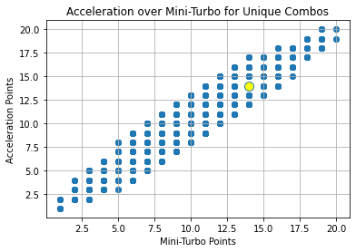

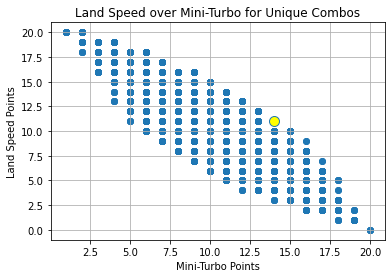

[figure not shown]

```python
#this code block creates a point for the Waluigi-Wild Wiggler-Rollers combo and plots in on the three scatter plots
#driver 11 is waluigi
#body 24 is the wild wiggler
#tire 2 are the rollers
#glider 13 is the paper glider
wwwr_build = driver_df.loc[11].drop("Driver") + body_df.loc[24].drop("Body") + tire_df.loc[2].drop("Tire") + glider_df.loc[13].drop("Glider")

plt.scatter(all_builds['MT'], all_builds['AC'])
x=wwwr_build[4] #mini turbo
y=wwwr_build[1] #accl
plt.plot(x,y, marker="o", markerfacecolor="yellow", markersize = 10)
plt.xlabel("Mini-Turbo Points")
plt.ylabel("Acceleration Points")
plt.title("Acceleration over Mini-Turbo for Unique Combos")
plt.grid()
plt.show()

plt.scatter(all_builds['MT'], all_builds['SL'])
x=wwwr_build[4] #mini turbo
y=wwwr_build[5] #speed
plt.plot(x,y, marker="o", markerfacecolor="yellow", markersize = 10)
plt.xlabel("Mini-Turbo Points")
plt.ylabel("Land Speed Points")
plt.title("Land Speed over Mini-Turbo for Unique Combos")
plt.grid()
plt.show()

plt.scatter(all_builds['SL'], all_builds['AC'])
x=wwwr_build[5] #speed
y=wwwr_build[1] #accl
plt.plot(x,y, marker="o", markerfacecolor="yellow", markersize = 10)
plt.xlabel("Acceleration Points")
plt.ylabel("Land Speed Points")
plt.title("Land Speed over Acceleration for Unique Combos")
plt.grid()
plt.show()
```

## Insight

As shown from the scatterplots above, there is good reason for all the hype around the Waluigi combination. This data shows that Waluigi is Pareto Efficient in both speed vs mini-turbo category and in the speed vs acceleration category. The next time you see a Waluigi riding a Wild Wiggler online, maybe you should join them!

## Interesting, but not Useful Data

### Data Collection

- Some vehicle statistics (i.e. weight, acceleration, etc.) are not visible in-game, and their point values must be found in the game's files or through testing.